# Homework 2 - IE582 - Fall 2020

Irem Arica

11 12 2020

```r
# reading the data
setwd("~/Desktop/Homework2")
x.train <- read.table("~/Desktop/Homework2/uWaveGestureLibrary_X_TRAIN",
    quote = "\"", comment.char = "")
y.train <- read.table("~/Desktop/Homework2/uWaveGestureLibrary_Y_TRAIN",
    quote = "\"", comment.char = "")
z.train <- read.table("~/Desktop/Homework2/uWaveGestureLibrary_Z_TRAIN",
    quote = "\"", comment.char = "")
colnames(x.train) <- c("class", paste0("t", 1:315))
colnames(y.train) <- c("class", paste0("t", 1:315))
colnames(z.train) <- c("class", paste0("t", 1:315))

# libraries
library(data.table, warn.conflicts = FALSE)
library(ggplot2, warn.conflicts = FALSE)
library(dplyr, warn.conflicts = FALSE)
library(scatterplot3d, warn.conflicts = FALSE)
```

## Task A

For visualization of gestures, position values can be used. At first, velocity information for each axis can be calculated by computing the cumulative sum of acceleration over time. Velocity vectors are created as follows.

```r
# creating velocity vectors
class <- as.data.frame(x.train$class)
x.velocity <- c()
for (i in 1:896) {
    x.velocity <- as.data.frame(rbind(x.velocity, cumsum(as.matrix(x.train[i,
        2:316], ncol = 1, nrow = 315))))
}
x.velocity <- cbind(class, x.velocity)
colnames(x.velocity) <- c("class", paste0("t", 1:315))

y.velocity <- c()
for (i in 1:896) {
    y.velocity <- as.data.frame(rbind(y.velocity, cumsum(as.matrix(y.train[i,
        2:316], ncol = 1, nrow = 315))))
}
y.velocity <- cbind(class, y.velocity)
colnames(y.velocity) <- c("class", paste0("t", 1:315))

z.velocity <- c()
for (i in 1:896) {
    z.velocity <- as.data.frame(rbind(z.velocity, cumsum(as.matrix(z.train[i,
        2:316], ncol = 1, nrow = 315))))
}
z.velocity <- cbind(class, z.velocity)
colnames(z.velocity) <- c("class", paste0("t", 1:315))
```

Secondly, position information for each axis can be calculated by computing the cumulative sum of velocity over time. Position vectors are created as follows.

```r
# creating position vectors
x.position <- c()
for (i in 1:896) {
    x.position <- as.data.frame(rbind(x.position, cumsum(as.matrix(x.velocity[i,
        2:316], ncol = 1, nrow = 315))))
}
x.position <- cbind(class, x.position)
colnames(x.position) <- c("class", paste0("t", 1:315))

y.position <- c()
for (i in 1:896) {
    y.position <- as.data.frame(rbind(y.position, cumsum(as.matrix(y.velocity[i,
        2:316], ncol = 1, nrow = 315))))
}
y.position <- cbind(class, y.position)
colnames(y.position) <- c("class", paste0("t", 1:315))

z.position <- c()
for (i in 1:896) {
    z.position <- as.data.frame(rbind(z.position, cumsum(as.matrix(z.velocity[i,
        2:316], ncol = 1, nrow = 315))))
}
z.position <- cbind(class, z.position)
colnames(z.position) <- c("class", paste0("t", 1:315))
```

After calculation of velocity and position vectors, an instance should be selected from each class. The row numbers of instances that will be visualized can be determine by selecting third value.

```r
ins.no <- c()
for (i in 1:8) {
    ins.no <- c(ins.no, which(x.velocity$class == i)[3])
}
```

Scatterplots for each gesture are below.

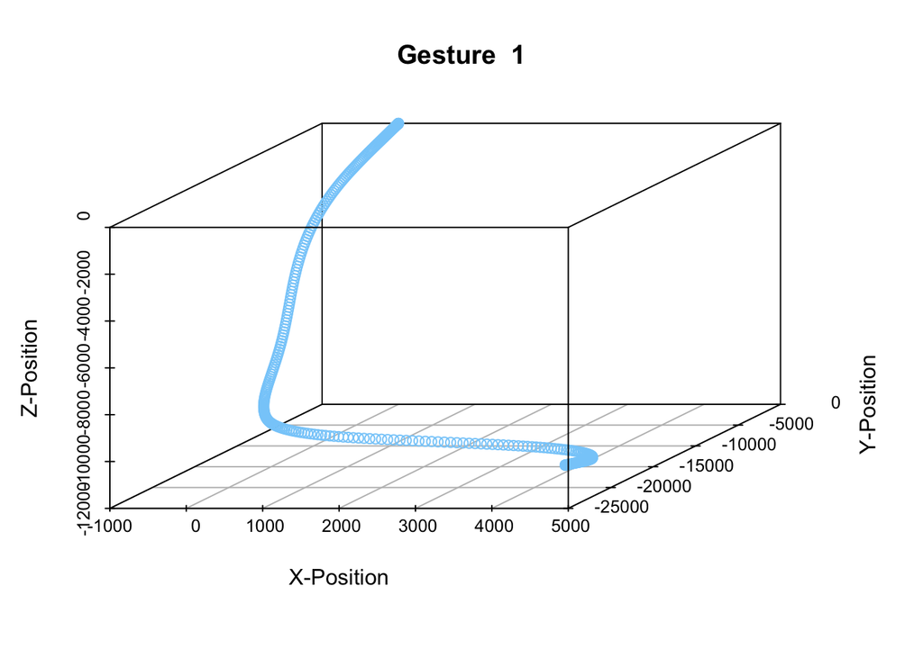

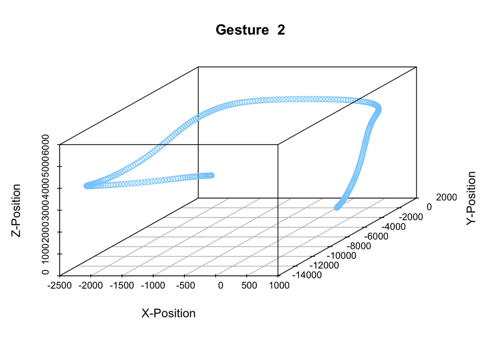

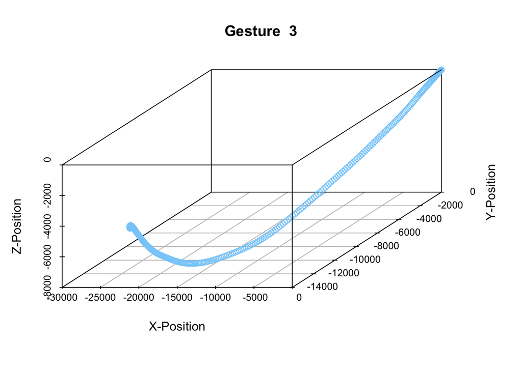

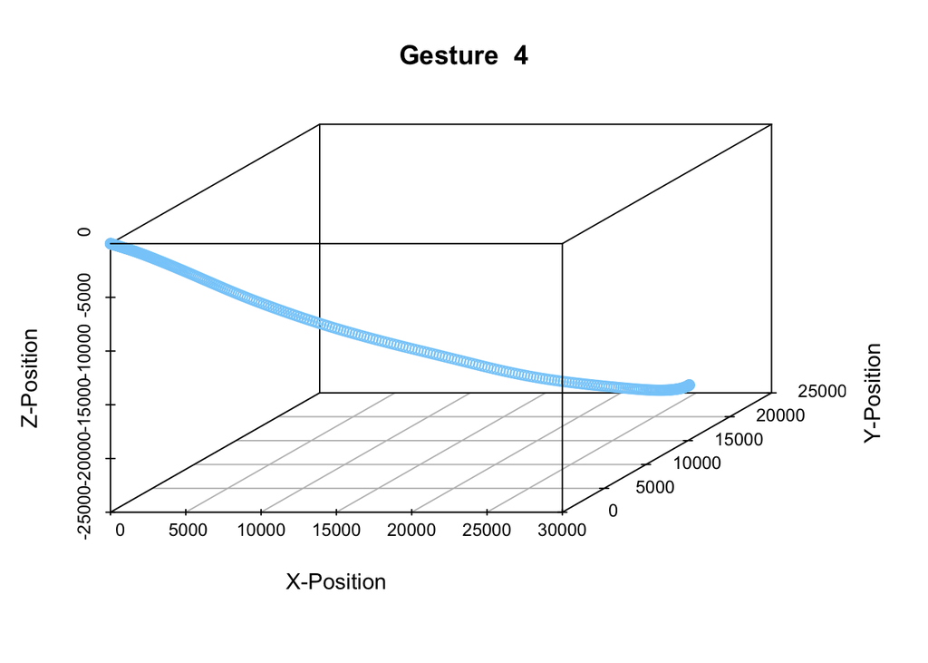

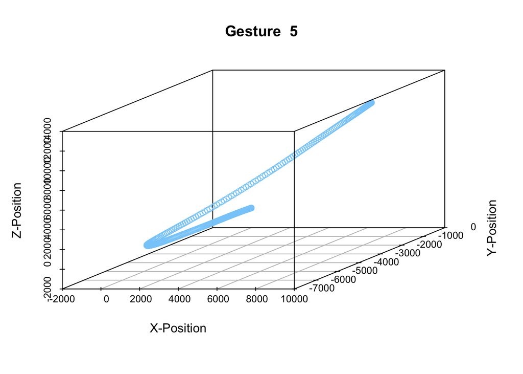

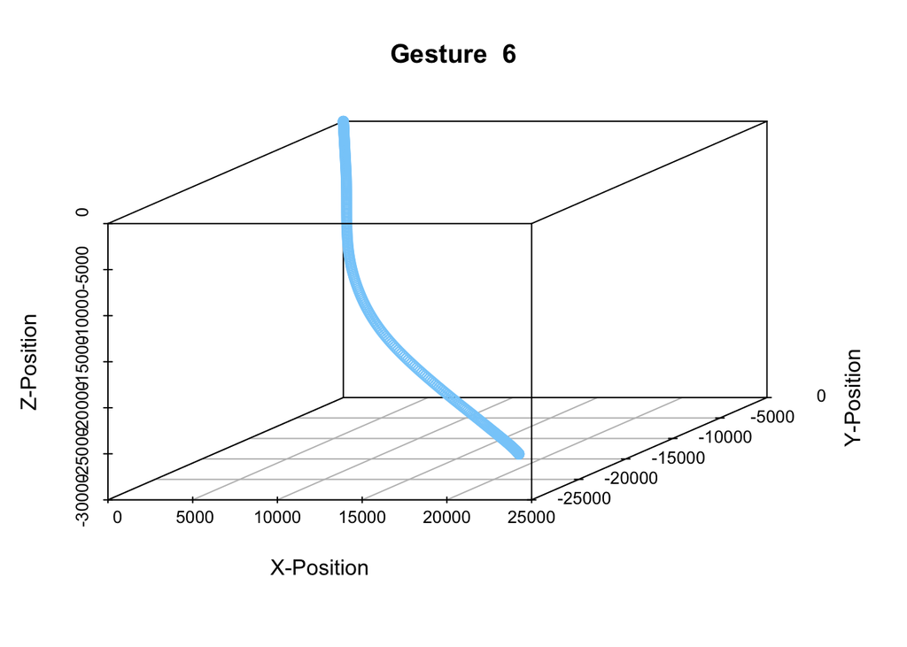

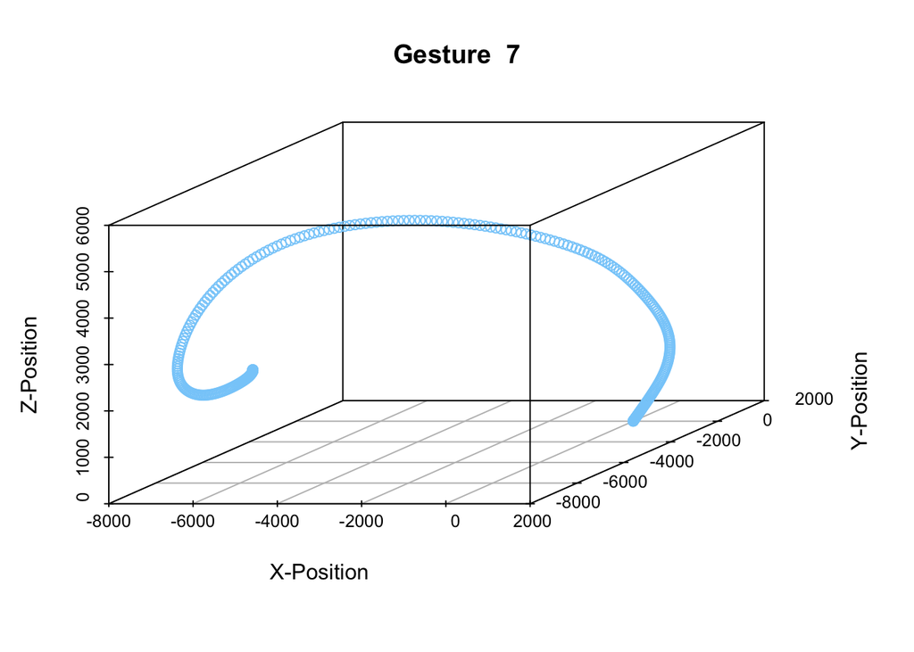

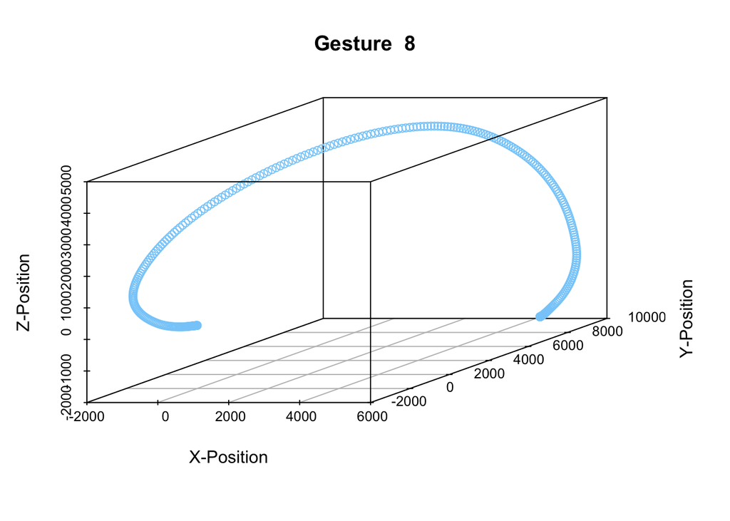

```r
x.position <- as.matrix(x.position, ncol = 316, nrow = 896)
y.position <- as.matrix(y.position, ncol = 316, nrow = 896)
z.position <- as.matrix(z.position, ncol = 316, nrow = 896)

for (i in 1:8) {
    scatterplot3d(x.position[ins.no[i], 2:316], y.position[ins.no[i],
        2:316], z.position[ins.no[i], 2:316], main = paste("Gesture ",
        i), xlab = "X-Position", ylab = "Y-Position", zlab = "Z-Position",
        color = "lightskyblue")
}
```

# Part B

For transforming the data into long format, variables such as Time Series ID, Time Index and Class generated. For X, Y and Z columns, location information on these axes are used.

```r
# long format of data
x.position <- as.data.frame(x.position)
y.position <- as.data.frame(y.position)
z.position <- as.data.frame(z.position)

time.series.id <- as.matrix(rep(1:896, each = 315), ncol = 1)
time.index <- as.matrix(rep(1:315, 896), ncol = 1)
class <- as.matrix(rep(x.train$class, each = 315), ncol = 1)

x.col <- c()
for (i in 1:nrow(x.position)) {
    x.col <- rbind(x.col, t(x.position[i, 2:316]))
}
y.col <- c()
for (i in 1:nrow(y.position)) {
    y.col <- rbind(y.col, t(y.position[i, 2:316]))
}
z.col <- c()
for (i in 1:nrow(z.position)) {
    z.col <- rbind(z.col, t(z.position[i, 2:316]))
}
```

After each column are created, they are combined for achieving long format. First 6 rows of long format of data is below.

```r
train.long <- as.data.frame(cbind(time.series.id, time.index,
    x.col, y.col, z.col, class), ncol = 6)
colnames(train.long) <- c("time.series.id", "time.index", "x.col",
    "y.col", "z.col", "class")
head(train.long)
```

```
##    time.series.id time.index      x.col      y.col      z.col class
## t1              1          1 -0.3042432  -2.119396  -1.528965     6
## t2              1          2 -0.9127296  -6.358187  -4.586895     6
## t3              1          3 -1.8254593 -12.716375  -9.173791     6
## t4              1          4 -3.0424321 -21.193958 -15.289651     6
## t5              1          5 -4.5636481 -31.790937 -22.934476     6
## t6              1          6 -6.3891074 -44.507312 -32.108267     6
```

PCA is used for reducing the data from 3D to 1D. In the analysis, only the X, Y and Z columns of the long format of data are used. Summary of PCA results are as follows.

```r
# applying pca
pca <- princomp(train.long[, 3:5], cor = T)
summary(pca, loadings = TRUE)
```

```
## Importance of components:
##                           Comp.1    Comp.2    Comp.3
## Standard deviation     1.2724995 1.0380930 0.5505524
## Proportion of Variance 0.5397517 0.3592124 0.1010360
## Cumulative Proportion  0.5397517 0.8989640 1.0000000
##
## Loadings:
##       Comp.1 Comp.2 Comp.3
## x.col  0.209  0.908  0.362
## y.col  0.723  0.105 -0.683
## z.col  0.658 -0.404  0.635
```

According to proportion of variance values, 54% of the variance is explained by the first component of PCA. Second component explains 36% and third component explains 10% of total variance. Keeping the first two components can be meaningful since they explain 90% of the total variance of original dataset. However, in this part, we should use only the first component for reduction from 3D to 1D. First component is calculated with multiplying the original data with coeffients in the analysis results.

```r
pca.data <- train.long
pca.data$comp1 <- 0.209 * pca.data$x.col + 0.723 * pca.data$y.col +
    0.658 * pca.data$z.col
```

For visualizing the reduced dimensions as time series, random two instances from each class are selected at first. Then, their time series are visualized in a single plot.

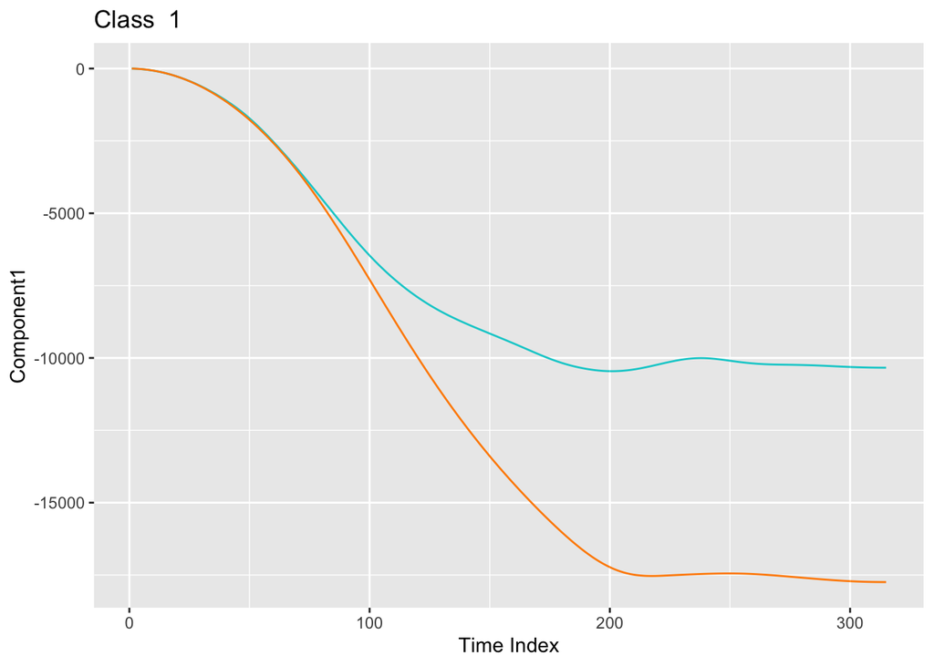

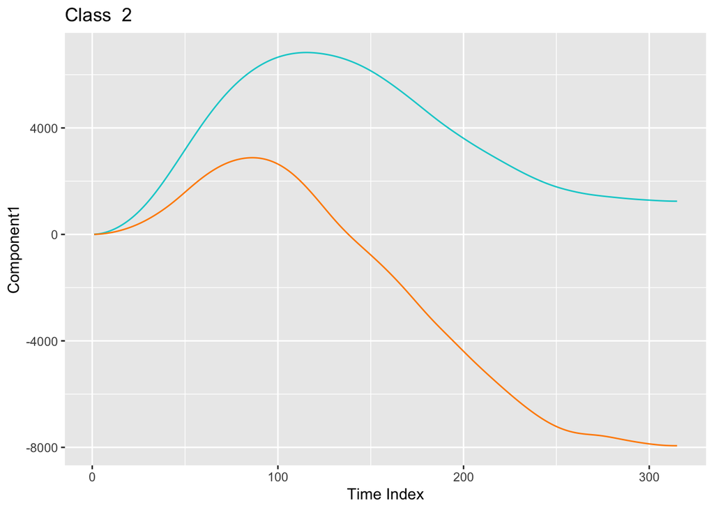

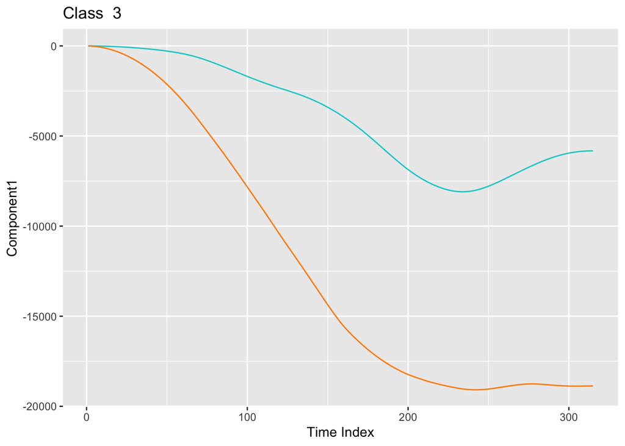

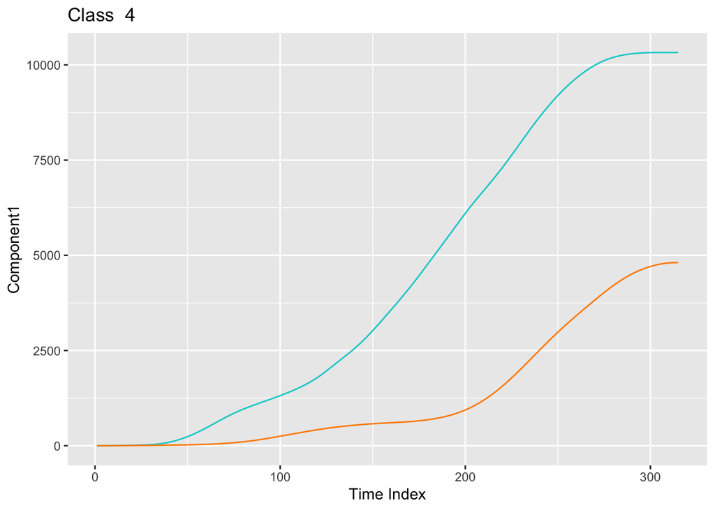

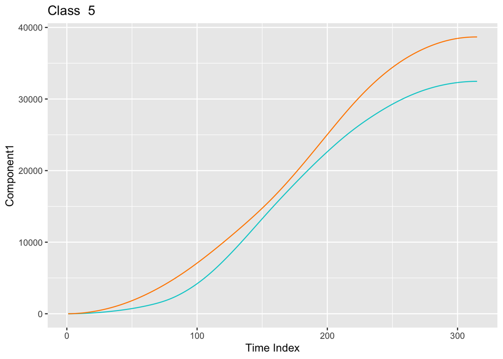

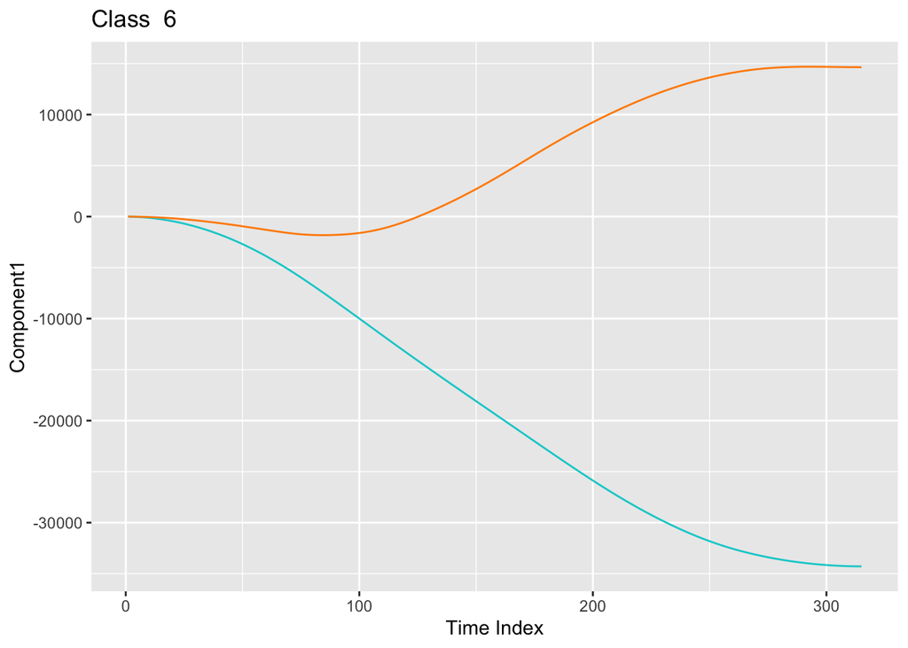

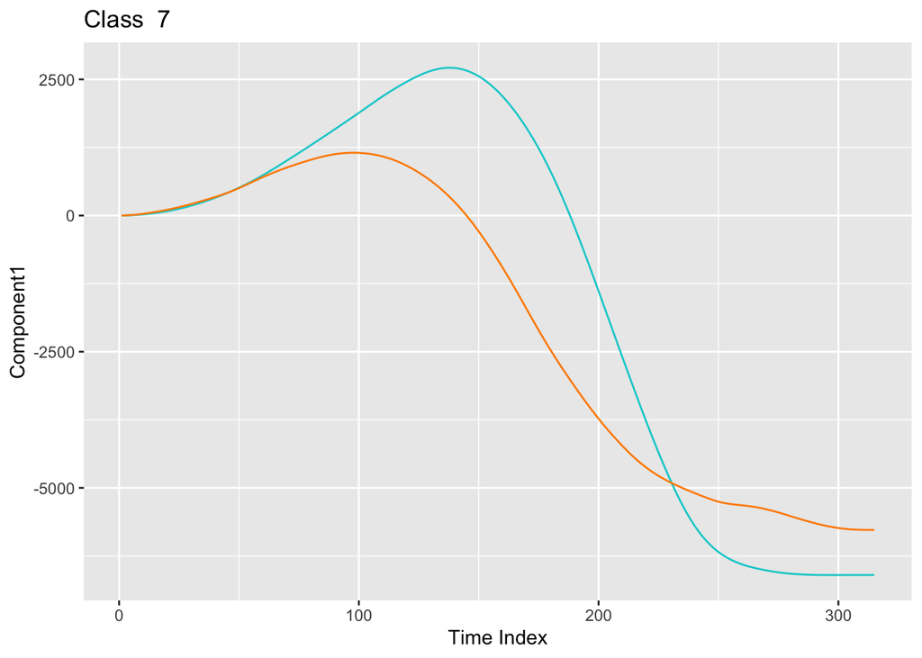

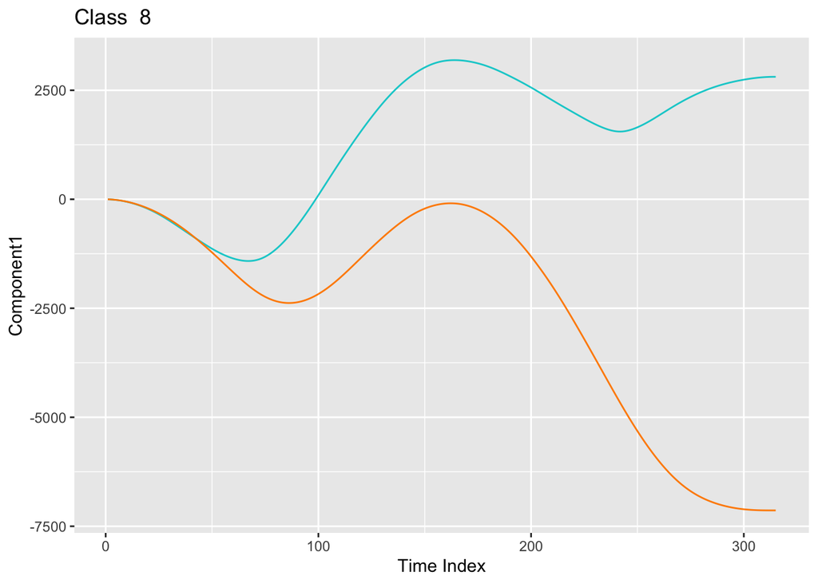

```r
# selecting random time series for each class
index1 <- c()
index2 <- c()
for (i in 1:8) {
    index1 <- c(index1, unique(pca.data$time.series.id[which(pca.data$class ==
        i)])[24])
    index2 <- c(index2, unique(pca.data$time.series.id[which(pca.data$class ==
        i)])[75])
}

# visualization of reduced dimensions as time series in a
# single plot
for (i in 1:8) {
    plot <- ggplot() + geom_line(aes(x = time.index[which(time.series.id ==
        index1[i])], y = pca.data$comp1[which(time.series.id ==
        index1[i])]), color = "darkturquoise") + geom_line(aes(x = time.index[which(time.series.id ==
        index2[i])], y = pca.data$comp1[which(time.series.id ==
        index2[i])]), color = "darkorange") + ylab("Component1") +
        xlab("Time Index") + ggtitle(paste("Class ", i))
    print(plot)
}
```

# Part C

PCA is applied with filtering the data for each class. Results of each PCA are given below.

```r
# pca for each class
for (i in 1:8) {
    pca.class <- princomp(subset(pca.data, class == i)[, 3:5],
        cor = T)
    cat("\n", "The PCA results for Class ", i, "\n")
    print(summary(pca.class, loadings = TRUE))
}
```

```
##
##  The PCA results for Class  1
## Importance of components:
##                           Comp.1    Comp.2    Comp.3
## Standard deviation     1.2932492 1.0091473 0.5559931
## Proportion of Variance 0.5574978 0.3394594 0.1030428
## Cumulative Proportion  0.5574978 0.8969572 1.0000000
##
## Loadings:
##       Comp.1 Comp.2 Comp.3
## x.col  0.119  0.973  0.198
## y.col  0.693 -0.224  0.685
## z.col  0.711        -0.701
##
##  The PCA results for Class  2
## Importance of components:
##                           Comp.1    Comp.2    Comp.3
## Standard deviation     1.1286537 0.9457021 0.9120243
## Proportion of Variance 0.4246197 0.2981175 0.2772628
## Cumulative Proportion  0.4246197 0.7227372 1.0000000
##
## Loadings:
##       Comp.1 Comp.2 Comp.3
## x.col  0.535  0.814  0.224
## y.col  0.613 -0.192 -0.767
## z.col  0.581 -0.548  0.602
##
##  The PCA results for Class  3
## Importance of components:
##                           Comp.1    Comp.2    Comp.3
## Standard deviation     1.2156489 1.0027730 0.7187794
## Proportion of Variance 0.4926008 0.3351846 0.1722146
## Cumulative Proportion  0.4926008 0.8277854 1.0000000
##
## Loadings:
##       Comp.1 Comp.2 Comp.3
## x.col  0.709         0.705
## y.col  0.371  0.847 -0.380
## z.col -0.599  0.532  0.599
##
```

[output cut: 49 more lines]

```
## y.col  0.632  0.207 -0.747
## z.col  0.496 -0.849  0.184
##
##  The PCA results for Class  8
## Importance of components:
##                           Comp.1    Comp.2    Comp.3
## Standard deviation     1.2203138 0.9683089 0.7571078
## Proportion of Variance 0.4963886 0.3125407 0.1910707
## Cumulative Proportion  0.4963886 0.8089293 1.0000000
##
## Loadings:
##       Comp.1 Comp.2 Comp.3
## x.col  0.664  0.253  0.704
## y.col  0.337 -0.941
## z.col  0.668  0.223 -0.710
```

According to the results, the first component explains 50-60% of the total variance for almost each class. Only in Class 5, this value increases to 65% and differ from the others. Also, explained variance with first compenent is smaller than the other in Class 2, with %42.

The proportion of explained variance with the first two components is in the range of 80-90% for almost all classes. This value varies especially in the two classes. First two components explains only 70% of variance in Class 2 and explains %97 of variance in Class 5.

These results are similar to the PCA results that applied to the all data.

# Part D

The distance between the time series for each axis is computed using the original representation. Euclidean distance is used in calculations. First 5 columns and rows of distance matrix can be seen in the below.

```r
# creating distance matrix
x.distance <- dist(x.train[, 2:316], method = "euclidean", diag = TRUE,
    upper = TRUE)
y.distance <- dist(y.train[, 2:316], method = "euclidean", diag = TRUE,
    upper = TRUE)
z.distance <- dist(z.train[, 2:316], method = "euclidean", diag = TRUE,
    upper = TRUE)
dist.matrix <- as.matrix(x.distance + y.distance + z.distance)
dist.matrix[1:5, 1:5]
```

```
##          1        2        3        4        5
## 1  0.00000 87.68508 79.49081 86.40700 70.03667
## 2 87.68508  0.00000 44.96116 63.11674 54.75039
## 3 79.49081 44.96116  0.00000 74.07190 51.52769
## 4 86.40700 63.11674 74.07190  0.00000 76.31456
## 5 70.03667 54.75039 51.52769 76.31456  0.00000
```

Multidimensional scaling is applied to distance matrix for representing each time series on 2D feature space.

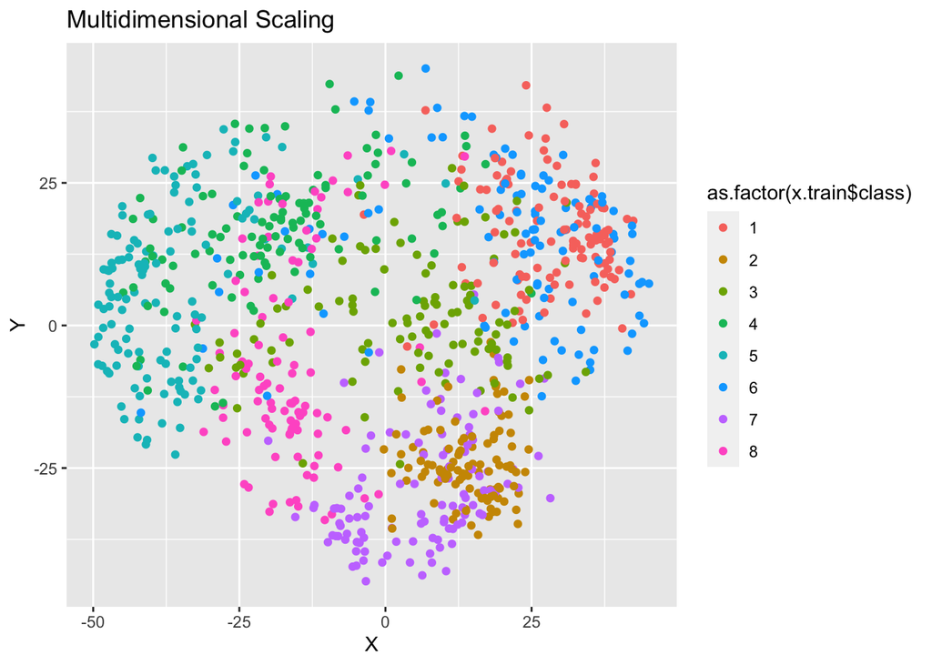

```r
# multidimensional scaling
mds <- cmdscale(dist.matrix, eig = TRUE, k = 2)
x <- mds$points[, 1]
y <- mds$points[, 2]
ggplot() + geom_point(aes(x = x, y = y, colour = as.factor(x.train$class))) +
    ylab("Y") + xlab("X") + ggtitle("Multidimensional Scaling")
```

The aim of this visualization is classification. Most classes are concentrated in a spesific region. However, in some places these regions are intersect. Especially, Class 4 and Class 5 are concentrated in the left part of the plot and they cannot be seperated from each other easily. There is a similar situation for Class 1 and Class 6 that concentrated on the right. Finally, Class 3 is spread over a larger area compared to others and it is hard to seperate from other classes.